# Animating metric MDS: paraboloid and saddle

How does a random cloud become a curved surface when only its pairwise distances are known? The SGD backend of `metric.mds()` adjusts a pair of points at a time. Its optional **update trace** lets us inspect those actual states and animate the reconstruction.

This example reconstructs a paraboloid and a saddle from the ambient distances between 250 points. Both have two intrinsic dimensions, but preserving their straight-line distances generally requires three embedding dimensions. Distances along the surface would define a different reconstruction problem.

The vignette uses the tracing interface in the development version of grip (after 0.2.0). It rebuilds the fits from public R calls, without a separate instrumented solver or saved fitting results. The optional **ivue** and **rgl** packages provide the interactive view; numerical examples still run without them. See Metric MDS for other weighting choices.

## Sample the same points on two surfaces

On the unit disk, take $z=x^2+y^2$ for the paraboloid and $z=x^2-y^2$ for the saddle. Both have area element $\sqrt{1+4r^2}\,r\,dr\,d\theta$. To sample uniformly over surface area, draw $U$ uniformly on $[0,1]$, an independent uniform angle, and use

$$r=\sqrt{\frac{\{1+U(5^{3/2}-1)\}^{2/3}-1}{4}}.$$

Thus the same sampled $x,y$ positions give a surface-area sample on either surface. Only heights and target distances change.

```r
set.seed(20261020)
n <- 250L
u <- runif(n)
theta <- runif(n, 0, 2*pi)
r <- sqrt(((1 + u*(5^(3/2) - 1))^(2/3) - 1)/4)
paraboloid <- cbind(x = r*cos(theta), y = r*sin(theta), z = r^2)
saddle <- paraboloid
saddle[, "z"] <- saddle[, "x"]^2 - saddle[, "y"]^2
stopifnot(identical(paraboloid[, 1:2], saddle[, 1:2]))
```

We fit all $250\times249/2=31{,}125$ unordered pairs. The view draws only 1,000 sampled chords to keep the surface visible; this display subset does not change the fit.

## Choose the target error and the initial cloud

Let $d_{ij}>0$ be a target distance and $\widehat d_{ij}$ the distance in the current embedding. We display the mean squared relative error

$$S=\frac{1}{m}\sum_{i<j}
\left(\frac{\widehat d_{ij}-d_{ij}}{d_{ij}}\right)^2,
\qquad m=31{,}125.$$

`pair.weights = "inverse_squared"` weights each squared distance residual by $1/d_{ij}^2$, giving this relative-error objective up to a constant factor. The chart shows **$100S$**; the supplementary readout shows **$100\sqrt S$**, the RMS relative error in percent. Neither is the aggregate relative RMS error $\sqrt{\sum(\widehat d-d)^2/\sum d^2}$. We recompute $S$ from each saved state rather than substituting the solver’s diagnostic stress.

```r
truth <- paraboloid
target <- as.numeric(dist(truth))
relative.stress <- function(X) mean((as.numeric(dist(X))/target - 1)^2)

set.seed(20261021)
initial <- matrix(rnorm(n*3L), n, 3L)
initial <- sweep(initial, 2, colMeans(initial))
ratio <- as.numeric(dist(initial))/target
initial <- initial * sum(ratio)/sum(ratio^2)
```

The final line chooses the positive scale minimizing the initial cloud’s relative error. This initialization uses target distances, not the true coordinates. Display alignment below is a separate operation.

## Record genuine SGD states

Enable recording through `sgd.control$trace`. The call below records every 32nd examined pair, plus the initial state and the epoch endpoint. One start is required. `keep.state = TRUE` allows the next call to continue the same trajectory, including the random-generator state and learning-rate schedule.

```r
control <- list(
  scheduler = "hybrid", learning.rate = 0.5, final.rate = 0.01,
  switch.ratio = 0.4, schedule.epochs = 500L,
  checkpoint.every = 1L, keep.state = TRUE,
  trace = list(every = 32L, max.bytes = 64*1024^2)
)
fit <- surface.epoch(
  distance.matrix = as.matrix(dist(truth)), init = initial, dim = 3L,
  backend = "sgd", n.init = 1L, max.iter = 1L, seed = 20261022L,
  pair.weights = "inverse_squared", diagnostics = FALSE,
  sgd.control = control
)
head(fit$update_trace$steps)
```

```
#>   epoch update_in_epoch pair_updates
#> 1     0               0            0
#> 2     1              32           32
#> 3     1              64           64
#> 4     1              96           96
#> 5     1             128          128
#> 6     1             160          160
```

`fit$update_trace$coordinates` contains raw matrices in **input-distance units**, with no alignment. Its `steps` table records the epoch, the position within that epoch, and the absolute number of examined pairs (`pair_updates`). An examined pair can produce no movement; recording it does not change the algorithm or consume extra random numbers. The existing `fit$trace` is the separate epoch-level diagnostic history.

```r
recorded <- fit$update_trace
first <- recorded$coordinates[[1L]]
last <- tail(recorded$coordinates, 1L)[[1L]]
c(initial = relative.stress(first), after_one_epoch = relative.stress(last))
```

```
#>         initial after_one_epoch
#>     0.738738329     0.001816587
```

The last raw state need not equal `fit$coords`: the returned fit can select and scale-profile a best checkpoint. For an honest animation of the solver, use `update_trace$coordinates` consistently.

## Continue, stop, and keep a compact playback sequence

The next call adds one epoch without restarting:

```r
next.fit <- surface.epoch(resume = fit, max.iter = 1L)
stopifnot(identical(next.fit$update_trace$coordinates[[1L]], last))
tail(next.fit$update_trace$steps, 1L)
```

```
#>     epoch update_in_epoch pair_updates
#> 974     2           31125        62250
```

Each update trace covers **only that call**. Save wanted frames before replacing the fit, and omit the duplicated initial frame on continuation. The helper `surface.trace()` repeats this process for at most ten epochs, stopping earlier when $100S\leq10^{-12}$, evaluated at epoch endpoints. It preserves the demonstration’s 500-epoch hybrid rate schedule; stopping early does not compress that schedule into ten epochs.

For playback, it retains every 32nd update through update 1,024 of each epoch, then every 256th update, and every endpoint. All retained coordinates and errors are actual evaluated states, not interpolations. Individual updates can increase all-pair error even while an epoch improves the fit.

```r
cases <- list(
  paraboloid = surface.trace(paraboloid),
  saddle = surface.trace(saddle)
)
```

Completing an epoch budget is not a convergence certificate. Here the external stopping rule establishes only that the specified error threshold was reached on these synthetic targets.

## Align for display, without changing the fit

Each frame, including the initial cloud, is translated and orthogonally rotated or reflected to align corresponding points with the truth:

```r
align <- function(X, truth) {
  center <- colMeans(truth)
  centered <- sweep(X, 2, colMeans(X))
  decomposition <- svd(crossprod(centered, sweep(truth, 2, center)))
  sweep(centered %*% decomposition$u %*% t(decomposition$v), 2, center, "+")
}
aligned <- align(last, truth)
stopifnot(max(abs(as.numeric(dist(aligned)) - as.numeric(dist(last)))) < 1e-12)
```

There is **no rescaling** in this Procrustes alignment. It preserves distances and stress and is never fed back to the optimizer. It uses the known truth only to make the animation easier to follow; real datasets may lack such a reference. Independent alignment can rotate the whole displayed cloud even though a single raw SGD update moves at most two points.

## Watch the reconstruction

Installed documentation shows recorded states and their error curves below. Render with `options(grip.vignette.interactive = TRUE)` for playback. In that interactive view, choose a **Surface**, then press **Start**. The stages show the surface, the sample, the chords, the aligned random cloud, and saved SGD updates. The first epoch takes 16 seconds; subsequent epochs take four seconds at normal speed. **Stop**, **Reset**, the stage selector and the saved-update slider allow inspection. Point spheres keep their original height colors; reference points and chords can be toggled. The transparent surface stays in the original coordinate system.

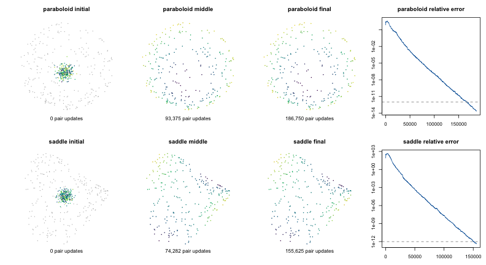

Static views show the initial, middle recorded and final states at a common scale. Gray points are the reference; colors retain original height. The error curves use every recorded state. For playback, install **ivue** and **rgl** and render with `options(grip.vignette.interactive = TRUE)`.

The chart uses a logarithmic vertical axis, with values below $10^{-15}$ placed at that display floor. The numerical readout retains the actual value. The dashed line marks the stopping threshold. Rendering happens in the browser; fitting and error evaluation have already happened in R.

| Surface | Epochs | Saved frames | Final 100 S | RMS relative error (%) | Stop |
| --- | --- | --- | --- | --- | --- |
| paraboloid | 6 | 901 | 2.00463e-14 | 1.41585e-06 | threshold |
| saddle | 5 | 751 | 4.18084e-13 | 6.46594e-06 | threshold |

Both examples use SGD, one start, sampling seed 20261020, initialization seed 20261021, fitting seed 20261022, and chord-display seed 20261023. The same Gaussian draw is scaled separately for the two target matrices. Results describe these realizations, not a comparison of optimizer performance.

## Record every pair, or reduce memory further

Set `trace = list(every = 1L, max.bytes = 256*1024^2)` to capture every examined pair. At 250 points in 3D, one epoch alone contains 31,126 coordinate matrices, roughly 178 MiB of coordinate payload. R objects, conversion and retained continuation state require additional memory. The trace cap bounds native recording allocation, not total process memory, and also counts against `sgd.control$max.workspace.bytes`.

The recorder plans allocation for the full **requested call budget**, even if a stopping rule could end sooner. Recording one epoch at a time avoids allocating ten epochs in advance. Our default `every = 32L` needs roughly 5.6 MiB of coordinate payload per epoch. Increasing `every` further saves memory without changing the fit.

For the original demonstration’s finer opening detail, run:

```r
# Run sequentially: allow room for R objects as well as native recording.
cases <- list(
  paraboloid = surface.trace(paraboloid, every = 1L, max.bytes = 256*1024^2),
  saddle = surface.trace(saddle, every = 1L, max.bytes = 256*1024^2)
)
surface.animation(cases)
```

This retains each of the first 32 updates, every 32nd update through 1,024, every 256th update thereafter, and each endpoint, throughout every epoch. Discarding unneeded frames affects playback density only. Leave `trace` unset (or set it to `NULL`) for ordinary fits: the untraced native update loop has no recording branches, copies, or buffers.

## Reuse the example and save an offline HTML file

The helper script and browser playback code are installed with grip:

```r
basename(system.file("scripts", c("metric-mds-animation.R",
                                 "metric-mds-animation.js"), package = "grip"))
```

```
#> [1] "metric-mds-animation.R"  "metric-mds-animation.js"
```

The complete surface, sphere styling, controls and stress curve can be saved as a self-contained widget. Install ivue, rgl, htmlwidgets and Pandoc first:

```r
source(system.file("scripts", "metric-mds-animation.R", package = "grip"))
X <- surface.sample()
Y <- X
Y[, "z"] <- Y[, "x"]^2 - Y[, "y"]^2
cases <- list(paraboloid = surface.trace(X), saddle = surface.trace(Y))
options(grip.vignette.interactive = TRUE)
widget <- surface.animation(cases)
htmlwidgets::saveWidget(widget, "metric-mds-surfaces.html", selfcontained = TRUE)
```

Only synthetic coordinates and recorded states are embedded. The saved HTML needs no R session or network connection for playback. To inspect the numerical trace without graphics, use `cases$paraboloid$raw`, `cases$paraboloid$steps`, and `cases$paraboloid$errors`.